# Machine Learning Project

Druce Vertes - drucev at sign gmail dot com

Wednesday, May 27, 2015

- Practical Machine Learning
- Coursera / Johns Hopkins / Data Science Specialization

# Classify Fitbit data for correct form in bicep curls

- Data file with ~160 data columns collected from Fitbit wearable devices - see http://groupware.les.inf.puc-rio.br/har
- Wearers performed bicep curls under supervision of instructor
- Instructor classified observation as correct or 4 types of incorrect form (5 classifications)
- Train a classifier to learn which observations are correct form

# Load libraries

```r
library(lattice)
library(ggplot2)
library(caret)
library(MASS)
library(Matrix)
library(Rcpp)
library(lme4)
library(arm)
library(caTools)
library(randomForest)
library(parallel)
library(splines)
library(survival)
library(gbm)
library(nnet)
library(kernlab)
library(plyr)
```

# Load data

```r
setwd("C:/Users/druce/R/MLproject2")

# download data
# download.file("https://d396qusza40orc.cloudfront.net/predmachlearn/pml-training.csv", "pml-training.csv")
# download.file("https://d396qusza40orc.cloudfront.net/predmachlearn/pml-testing.csv", "pml-testing.csv")

training<-read.csv('pml-training.csv',na.strings = c("NA","#DIV/0!", ""))
testing<-read.csv('pml-testing.csv',na.strings = c("NA","#DIV/0!", ""))

# set random seed for reproducibility
# sample(1:10000, 1)
set.seed(1105)
```

# Explore data

```r
table(training$classe)
```

```
##
##    A    B    C    D    E
## 5580 3797 3422 3216 3607
```

# Histogram

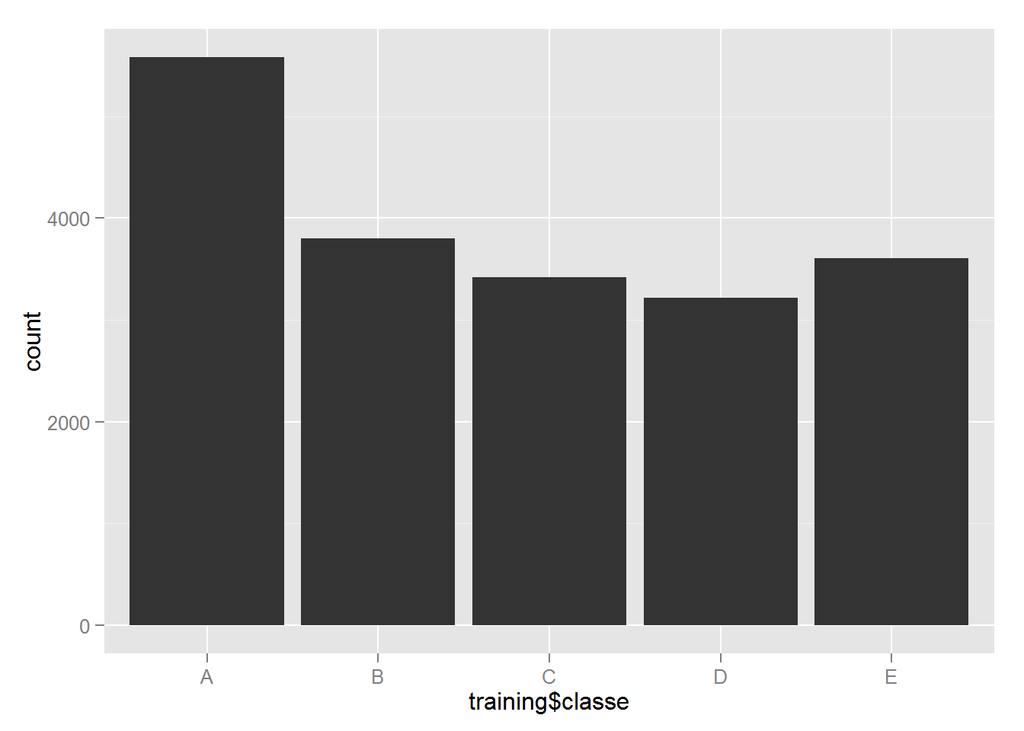

```r
qplot(training$classe, geom="histogram")
```

# Clean Data

Find columns with mostly NAs

```r
countMissing <- function(mycol) {
    return (sum(is.na(training[, mycol]))/ nrow(training))
}
countNAs <- data.frame(countNA=sapply(colnames(training), countMissing))
subset(countNAs, countNAs$countNA > 0.5)
```

```
##                            countNA
## kurtosis_roll_belt       0.9798186
## kurtosis_picth_belt      0.9809398
## kurtosis_yaw_belt        1.0000000
## skewness_roll_belt       0.9797676
## skewness_roll_belt.1     0.9809398
## skewness_yaw_belt        1.0000000
## max_roll_belt            0.9793089
## max_picth_belt           0.9793089
## max_yaw_belt             0.9798186
## min_roll_belt            0.9793089
## min_pitch_belt           0.9793089
## min_yaw_belt             0.9798186
## amplitude_roll_belt      0.9793089
## amplitude_pitch_belt     0.9793089
## amplitude_yaw_belt       0.9798186
## var_total_accel_belt     0.9793089
## avg_roll_belt            0.9793089
## stddev_roll_belt         0.9793089
## var_roll_belt            0.9793089
## avg_pitch_belt           0.9793089
## stddev_pitch_belt        0.9793089
## var_pitch_belt           0.9793089
## avg_yaw_belt             0.9793089
## stddev_yaw_belt          0.9793089
## var_yaw_belt             0.9793089
## var_accel_arm            0.9793089
## avg_roll_arm             0.9793089
## stddev_roll_arm          0.9793089
## var_roll_arm             0.9793089
## avg_pitch_arm            0.9793089
## stddev_pitch_arm         0.9793089
## var_pitch_arm            0.9793089
## avg_yaw_arm              0.9793089
## stddev_yaw_arm           0.9793089
## var_yaw_arm              0.9793089
## kurtosis_roll_arm        0.9832841
## kurtosis_picth_arm       0.9833860
## kurtosis_yaw_arm         0.9798695
## skewness_roll_arm        0.9832331
```

[output cut: 46 more lines]

```
## min_pitch_forearm        0.9793089
## min_yaw_forearm          0.9835898
## amplitude_roll_forearm   0.9793089
## amplitude_pitch_forearm  0.9793089
## amplitude_yaw_forearm    0.9835898
## var_accel_forearm        0.9793089
## avg_roll_forearm         0.9793089
## stddev_roll_forearm      0.9793089
## var_roll_forearm         0.9793089
## avg_pitch_forearm        0.9793089
## stddev_pitch_forearm     0.9793089
## var_pitch_forearm        0.9793089
## avg_yaw_forearm          0.9793089
## stddev_yaw_forearm       0.9793089
## var_yaw_forearm          0.9793089
```

# Omit columns with mostly NAs

- We see a number of summary columns with 97% of data NA
- We can safely delete them since we want to predict on individual observations

```r
colsToDeleteNA <- countNAs$countNA > 0.9
training <- training[, !colsToDeleteNA]
```

# Identify low-information columns

```r
nearzero <- nearZeroVar(training, saveMetrics=TRUE)
nearzero[nearzero$nzv==TRUE, ]
```

```
##            freqRatio percentUnique zeroVar  nzv
## new_window  47.33005    0.01019264   FALSE TRUE
```

# Delete descriptive columns

```r
# first 7 columns are descriptive, no predictive value and can be omitted
colsToDeleteLabels <- names(training)[1:7]
training <- training[,8:60]
```

# Correlation analysis

```r
# correlation analysis
mycorr <- cor(training[-53])
hicorr <- findCorrelation(mycorr, cutoff=0.8, verbose=FALSE)
colnames(training)[hicorr]
```

```
##  [1] "accel_belt_z"     "roll_belt"        "accel_belt_y"
##  [4] "accel_dumbbell_z" "accel_belt_x"     "pitch_belt"
##  [7] "accel_arm_x"      "accel_dumbbell_x" "magnet_arm_y"
## [10] "gyros_arm_y"      "gyros_forearm_z"  "gyros_dumbbell_x"
```

```r
corrmatrix <- matrix(mycorr[hicorr,hicorr], nrow=12, ncol=12, dimnames=list(colnames(training)[hicorr]))
colnames(corrmatrix)<- colnames(training)[hicorr]
corrmatrix[(corrmatrix > -0.8 & corrmatrix < 0.8) ] <- NA
```

# Correlation analysis - output

```r
# correlation analysis
corrmatrix
```

```
##                  accel_belt_z  roll_belt accel_belt_y accel_dumbbell_z
## accel_belt_z        1.0000000 -0.9920085   -0.9333854               NA
## roll_belt          -0.9920085  1.0000000    0.9248983               NA
## accel_belt_y       -0.9333854  0.9248983    1.0000000               NA
## accel_dumbbell_z           NA         NA           NA                1
## accel_belt_x               NA         NA           NA               NA
## pitch_belt                 NA         NA           NA               NA
## accel_arm_x                NA         NA           NA               NA
## accel_dumbbell_x           NA         NA           NA               NA
## magnet_arm_y               NA         NA           NA               NA
## gyros_arm_y                NA         NA           NA               NA
## gyros_forearm_z            NA         NA           NA               NA
## gyros_dumbbell_x           NA         NA           NA               NA
##                  accel_belt_x pitch_belt accel_arm_x accel_dumbbell_x
## accel_belt_z               NA         NA          NA               NA
## roll_belt                  NA         NA          NA               NA
## accel_belt_y               NA         NA          NA               NA
## accel_dumbbell_z           NA         NA          NA               NA
## accel_belt_x        1.0000000 -0.9657334          NA               NA
## pitch_belt         -0.9657334  1.0000000          NA               NA
## accel_arm_x                NA         NA           1               NA
## accel_dumbbell_x           NA         NA          NA                1
## magnet_arm_y               NA         NA          NA               NA
## gyros_arm_y                NA         NA          NA               NA
## gyros_forearm_z            NA         NA          NA               NA
## gyros_dumbbell_x           NA         NA          NA               NA
##                  magnet_arm_y gyros_arm_y gyros_forearm_z gyros_dumbbell_x
## accel_belt_z               NA          NA              NA               NA
## roll_belt                  NA          NA              NA               NA
## accel_belt_y               NA          NA              NA               NA
## accel_dumbbell_z           NA          NA              NA               NA
## accel_belt_x               NA          NA              NA               NA
## pitch_belt                 NA          NA              NA               NA
## accel_arm_x                NA          NA              NA               NA
## accel_dumbbell_x           NA          NA              NA               NA
## magnet_arm_y                1          NA              NA               NA
## gyros_arm_y                NA           1              NA               NA
## gyros_forearm_z            NA          NA       1.0000000       -0.9144764
## gyros_dumbbell_x           NA          NA      -0.9144764        1.0000000
```

# Correlation analysis - conclusion

- We could delete highly correlated columns and lose a little signal
- We could do PCA decomposition for dimensionality reduction and orthogonality
- Only 12 columns, let’s try to classify with and without PCA and see which works better

# Explore PCA decomposition

preProcess(pcaframe, method = c(“center”, “scale”,“pca”))

```r
# PCA analysis
pcaframe<-training[-53]
preProc1 <- preProcess(pcaframe, method = c("center", "scale","pca"))
preProc1
```

```
##
## Call:
## preProcess.default(x = pcaframe, method = c("center", "scale", "pca"))
##
## Created from 19622 samples and 52 variables
## Pre-processing: centered, scaled, principal component signal extraction
##
## PCA needed 25 components to capture 95 percent of the variance
```

```r
# look at contributors to 1st PCA component
head(sort(preProc1$rotation[,1]))
```

```
##      accel_belt_y         roll_belt  total_accel_belt          yaw_belt
##        -0.3168012        -0.3076717        -0.3041918        -0.2010722
##  accel_dumbbell_x magnet_dumbbell_x
##        -0.1702179        -0.1687782
```

```r
head(sort(-preProc1$rotation[,1]))
```

```
##      accel_belt_z       accel_arm_y   accel_forearm_x  accel_dumbbell_y
##        -0.3165883        -0.2689201        -0.1920031        -0.1814922
##      gyros_belt_z magnet_dumbbell_z
##        -0.1795832        -0.1706385
```

# Plot some significant variables v. each other

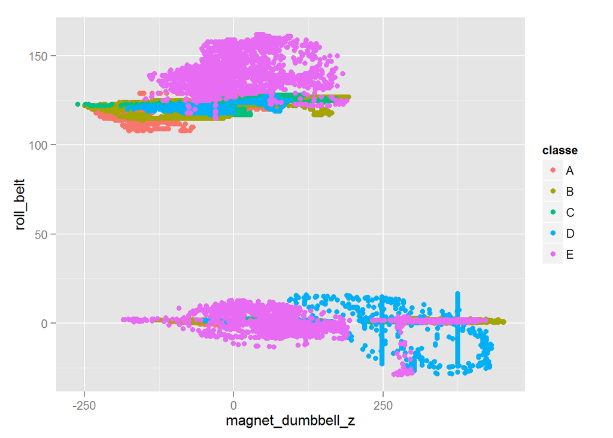

```r
qplot(magnet_dumbbell_z, roll_belt, data=training, color=classe)
```

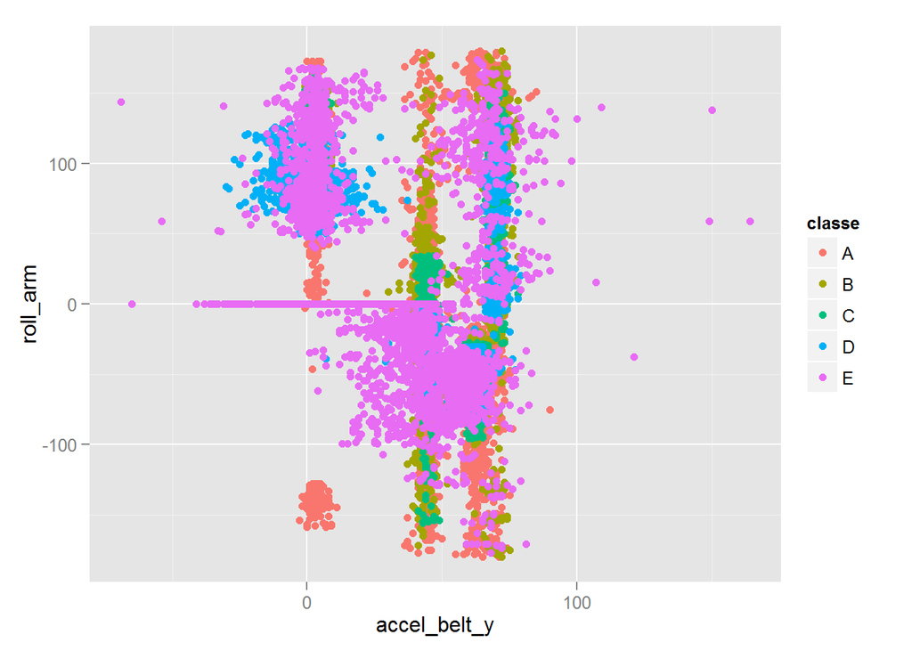

```r
qplot(accel_belt_y, roll_arm, data=training, color=classe)
```

# Plot top 2 PCA components v. each other

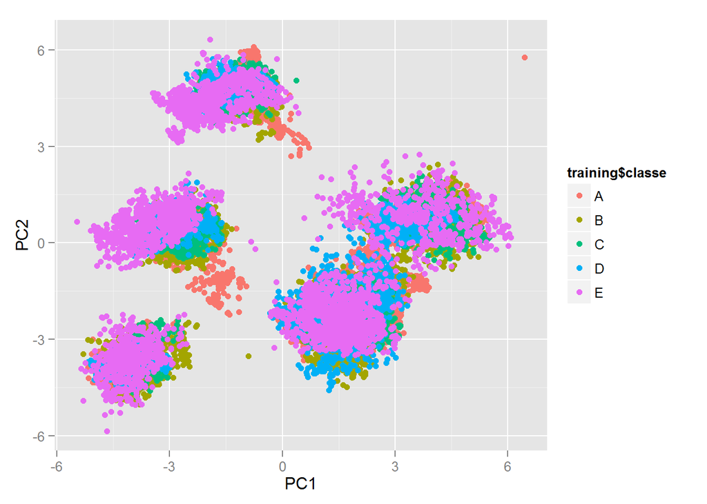

```r
PCAtraining <- predict(preProc1, pcaframe)
qplot(PC1, PC2, data=PCAtraining, color=training$classe)
```

# PCA - Conclusion

- 25 components capture 95% of variation from original 52
- The variables show some promising grouping
- PCA components group the observations into 5 clear groups
- But they don’t line up with the variable we want to predict (colors)
- It’s as if it’s separating individuals or another variable, not good/bad form

# PCA - Conclusion 2

- Plot vs. user names

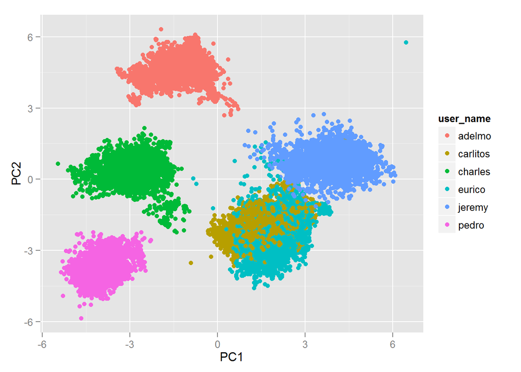

```r
training2<-read.csv('pml-training.csv',na.strings = c("NA","#DIV/0!", ""))
PCAtraining$user_name = training2$user_name
qplot(PC1, PC2, data=PCAtraining, col=user_name)
```

# Variable selection - discussion

- First 2 PCA components (capturing ~30% of variance) cluster pretty well by user_name, not by form
- So, should we add user_name to our list of predictors?
- If the goal is to create an algorithm that can predict on never-before-seen people, no.
- Since 30% of variation is explained by people, we might need a lot more people to create a truly user-independent algorithm.
- If the goal is to find a learning algorithm we can put into a device that learns about its user, it might make sense to include it.
- Test set contains same user names as training set.
- If the goal is to get highest possible accuracy, we should include it.
- If the goal is to get highest possible accuracy, could argue for including timestamp or sequence number, in case outcome is serially correlated.

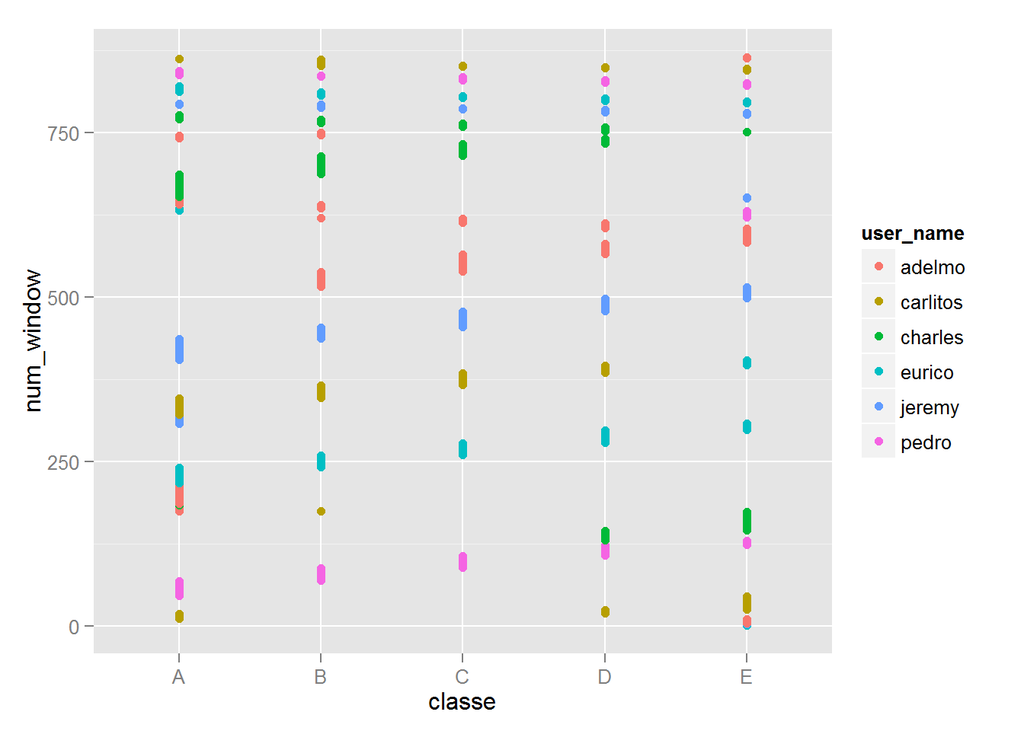

```r
qplot(classe, num_window, data=training2, color = user_name)
```

- We can see timestamp is quite a good predictor of classe
- Anyway, for grins, we’ll include user_name, and we won’t include timestamp or anything else.

```r
training$user_name <- training2$user_name
```

# Train classifiers - set up a loop with various methods

- Loop through methods
- Train on raw data, and preprocessing with PCA
- K-fold cross-validation with 10 folds (default)
- Run for ~4 hours, store results

```r
myMethods <- c("rf", "gbm", "LogitBoost", "nnet", "svmLinear", "svmRadial")
#myMethods <- c("rf")
trc_cv = trainControl(method="cv")
# center and scale for better performance on some methods
runModel <- function(mxpar) {
    return (train(classe ~ ., data=training, method=mxpar, preProcess=c("center", "scale"), trControl=trc_cv, verbose=FALSE))
}

runModelPCA <- function(mxpar) {
    return (train(classe ~ ., data=training, method=mxpar, preProcess=c("center", "scale","pca"), trControl=trc_cv, verbose=FALSE))
}

models <- list()
modelLabels <- list()
ACC <- list()
KPP <- list()
modelsStartTime <- list()

mycount <- 0
for (mx in myMethods) {
    # set.seed(1105)     # if you want to always use same folds
    # run model, store result

    mycount <- mycount+1
    modelsStartTime[[mycount]] <- Sys.time()
    print(sprintf ("Start %s : %s" , Sys.time(), mx))
    models[[mycount]] <- runModel(mx)
    modelLabels[[mycount]] <- models[[mycount]]$modelInfo$label
    ACC[[mycount]] <- max(models[[mycount]]$results$Accuracy)
    KPP[[mycount]] <- max(max(models[[mycount]]$results$Kappa))
    print(models[[mycount]])

    # PCA
    mycount <- mycount+1
    # set.seed(1105)
    modelsStartTime[[mycount]] <- Sys.time()
    print(sprintf ("Start %s : %s (PCA)" , Sys.time(), mx))
    models[[mycount]] <- runModelPCA(mx)
    modelLabels[[mycount]] <- sprintf("%s (PCA)", models[[mycount]]$modelInfo$label)
    ACC[[mycount]] <- max(models[[mycount]]$results$Accuracy)
    KPP[[mycount]] <- max(max(models[[mycount]]$results$Kappa))
    print(models[[mycount]])

}
```

```
## [1] "Start 2015-06-02 00:52:59 : rf"
## Random Forest
##
## 19622 samples
##    53 predictor
##     5 classes: 'A', 'B', 'C', 'D', 'E'
##
## Pre-processing: centered, scaled
## Resampling: Cross-Validated (10 fold)
##
## Summary of sample sizes: 17659, 17660, 17660, 17658, 17660, 17662, ...
##
## Resampling results across tuning parameters:
##
##   mtry  Accuracy   Kappa      Accuracy SD  Kappa SD
##    2    0.9947000  0.9932955  0.001383507  0.001750334
##   29    0.9952609  0.9940053  0.001979247  0.002502999
##   57    0.9904707  0.9879446  0.002606580  0.003298727
##
## Accuracy was used to select the optimal model using  the largest value.
## The final value used for the model was mtry = 29.
## [1] "Start 2015-06-02 01:56:40 : rf (PCA)"
```

```
## Random Forest
##
## 19622 samples
##    53 predictor
##     5 classes: 'A', 'B', 'C', 'D', 'E'
##
## Pre-processing: centered, scaled, principal component signal extraction
## Resampling: Cross-Validated (10 fold)
##
## Summary of sample sizes: 17660, 17661, 17660, 17659, 17660, 17659, ...
##
## Resampling results across tuning parameters:
##
##   mtry  Accuracy   Kappa      Accuracy SD  Kappa SD
##    2    0.9826719  0.9780770  0.003298127  0.004173802
##   29    0.9758439  0.9694394  0.003850303  0.004871236
##   57    0.9755889  0.9691173  0.003207011  0.004054452
##
## Accuracy was used to select the optimal model using  the largest value.
## The final value used for the model was mtry = 2.
## [1] "Start 2015-06-02 02:38:02 : gbm"
## Stochastic Gradient Boosting
##
## 19622 samples
##    53 predictor
##     5 classes: 'A', 'B', 'C', 'D', 'E'
##
## Pre-processing: centered, scaled
## Resampling: Cross-Validated (10 fold)
##
## Summary of sample sizes: 17659, 17659, 17660, 17659, 17660, 17660, ...
##
## Resampling results across tuning parameters:
##
##   interaction.depth  n.trees  Accuracy   Kappa      Accuracy SD
##   1                   50      0.7545110  0.6887900  0.007864122
##   1                  100      0.8224449  0.7752442  0.007643795
##   1                  150      0.8557238  0.8174202  0.008337909
##   2                   50      0.8549086  0.8161477  0.008684865
##   2                  100      0.9070941  0.8824359  0.007992765
```

[output cut: 231 more lines]

```
## Pre-processing: centered, scaled, principal component signal extraction
## Resampling: Cross-Validated (10 fold)
##
## Summary of sample sizes: 17659, 17661, 17659, 17660, 17661, 17660, ...
##
## Resampling results across tuning parameters:
##
##   C     Accuracy   Kappa      Accuracy SD  Kappa SD
##   0.25  0.8564365  0.8182141  0.009395994  0.011906874
##   0.50  0.8882886  0.8584735  0.006994871  0.008889099
##   1.00  0.9170831  0.8949560  0.004580355  0.005814074
##
## Tuning parameter 'sigma' was held constant at a value of 0.02616217
## Accuracy was used to select the optimal model using  the largest value.
## The final values used for the model were sigma = 0.02616217 and C = 1.
```

```r
modelsEndTime <- Sys.time()
modelsEndTime
```

```
## [1] "2015-06-02 05:38:27 EDT"
```

# Compare performance

```r
performance <- cbind(modelLabels,ACC,KPP)
performance
```

```
##       modelLabels
##  [1,] "Random Forest"
##  [2,] "Random Forest (PCA)"
##  [3,] "Stochastic Gradient Boosting"
##  [4,] "Stochastic Gradient Boosting (PCA)"
##  [5,] "Boosted Logistic Regression"
##  [6,] "Boosted Logistic Regression (PCA)"
##  [7,] "Neural Network"
##  [8,] "Neural Network (PCA)"
##  [9,] "Support Vector Machines with Linear Kernel"
## [10,] "Support Vector Machines with Linear Kernel (PCA)"
## [11,] "Support Vector Machines with Radial Basis Function Kernel"
## [12,] "Support Vector Machines with Radial Basis Function Kernel (PCA)"
##       ACC       KPP
##  [1,] 0.9952609 0.9940053
##  [2,] 0.9826719 0.978077
##  [3,] 0.9643262 0.954871
##  [4,] 0.8237698 0.7767599
##  [5,] 0.8964027 0.8683605
##  [6,] 0.6318316 0.5208719
##  [7,] 0.756044  0.6908199
##  [8,] 0.5963199 0.4889292
##  [9,] 0.8076136 0.7555619
## [10,] 0.5656405 0.4485072
## [11,] 0.9339006 0.9162333
## [12,] 0.9170831 0.894956
```

# Results

- Random forest (rf) classifies correctly 99.5% of observations
- PCA does not improve results on any method

# Variable importance

```r
RFclassifier <- models[[1]]
varImp(RFclassifier)
```

```
## rf variable importance
##
##   only 20 most important variables shown (out of 57)
##
##                      Overall
## roll_belt             100.00
## pitch_forearm          59.83
## yaw_belt               56.64
## pitch_belt             45.72
## magnet_dumbbell_z      44.66
## magnet_dumbbell_y      44.23
## roll_forearm           43.25
## accel_dumbbell_y       23.70
## accel_forearm_x        18.70
## magnet_dumbbell_x      18.15
## roll_dumbbell          17.65
## accel_belt_z           16.02
## magnet_belt_z          15.74
## accel_dumbbell_z       14.84
## magnet_forearm_z       14.66
## total_accel_dumbbell   14.62
## magnet_belt_y          13.96
## gyros_belt_z           12.97
## yaw_arm                12.48
## magnet_belt_x          11.66
```

- Interesting to compare vs. PCA
- A lot of overlap among top variables but some show a lot of variance but not much signal